# Evaluation_100x25

Kento Okuyama

2024-03-11

## (very) Brief introduction

In this document, we evaluate the implementation of our frequentist implementation of the non-linear regime-switching state-space (RSSS) model estimation based on simulated data. Our implementation is a special case in which the regime-switch occurs only in one direction (i.e., there’s no switch back). Our parameter optimization consists of 300 iteration steps based on Adam and 30 initializations of the starting parameter values.

In our implementation, our objective function **sumLik** is maximized based on the gradient vector and Adam. For evaluation purpose, we also have the score function **delta**. This is simply calculated as the summed squared error of the one-step-ahead (of the last observed time points) prediction of our intra-individual latent variables. Further, we also have **sensitivity** and **specificity** based on the one-step-ahead regime prediction results.

For further details of the model formulation as well as theoretical foundation, please refer to my master thesis ‘**Forecasting in regime-switching models that emerge from filtering and machine learning**’. In the following, we summarize our estimation results of 200 simulations (realizations of random variables). From now on, we focus exclusively on the ‘best’ result in each simulation study i.e., one that maximized our likelihood function among 30 initizalization * 300 iterations.

```r
setwd('C:/Users/kento/OneDrive - UT Cloud/Tuebingen/Research/Methods Center/Regime_Switching/Simulation/202311301300')
```

### N=100, T=25

```r
N <- 100; Nt <- 25
seeds <- c(1:200)
df_list <- lapply(seeds, function(seed) readRDS(paste('C:/Users/kento/OneDrive - UT Cloud/Tuebingen/Research/Methods Center/Regime_Switching/Simulation/202311301300/output/df__sim_', seed, '_N_', N, '_T_', Nt, '_O1_6_O2_3_L1_2.RDS', sep='')))
names(df_list) <- paste0('df_100x25_', seeds)
list2env(df_list, envir = .GlobalEnv)
```

```
## <environment: R_GlobalEnv>
```

```r
filter_list <- lapply(seeds, function(seed) readRDS(paste('C:/Users/kento/OneDrive - UT Cloud/Tuebingen/Research/Methods Center/Regime_Switching/Simulation/202311301300/output/filter__sim_', seed, '_N_', N, '_T_', Nt, '_O1_6_O2_3_L1_2.RDS', sep='')))
names(filter_list) <- paste0('filter_100x25_', seeds)
list2env(filter_list, envir = .GlobalEnv)
```

```
## <environment: R_GlobalEnv>
```

Before starting the evaluation of our estimated results, let’s take a look at the simulated data. We are particularly interested in the regime-switch occurence. We will summarize the percentage of subjects who made a regime switch in each of simulated realizations.

```r
# Function to remove a certain element from a vector
remove_element <- function(vector, element_to_remove) {
  vector <- vector[!vector %in% element_to_remove]
  return(vector)
}

sum(unlist(lapply(df_list, function(df) mean(df$S[,Nt]==2))) <= 10/75)
```

```
## [1] 96
```

```r
sum(unlist(lapply(df_list, function(df) mean(df$S[,Nt]==2))) > 10/75 & unlist(lapply(filter_list, function(filter) (filter$output_best$TP + filter$output_best$FP) / N) < 0.15))
```

```
## [1] 11
```

```r
element_to_remove <- (unlist(lapply(df_list, function(df) mean(df$S[,Nt]==2))) <= 10/75 * (75/8) * (8/75) + unlist(lapply(filter_list, function(filter) (filter$output_best$TP + filter$output_best$FP) / N) < 0.15)) > 0
element_to_remove2 <- as.numeric(which(element_to_remove==TRUE))

seeds2 <- remove_element(seeds, element_to_remove2)
seeds3 <- seeds2[-c(28,35)]

df_list2 <- lapply(seeds2, function(seed) readRDS(paste('output/df__sim_', seed, '_N_', N, '_T_', Nt, '_O1_6_O2_3_L1_2.RDS', sep='')))
names(df_list2) <- paste0('df_100x25_', seeds2)
list2env(df_list2, envir = .GlobalEnv)
```

```
## <environment: R_GlobalEnv>
```

```r
filter_list2 <- lapply(seeds2, function(seed) readRDS(paste('output/filter__sim_', seed, '_N_', N, '_T_', Nt, '_O1_6_O2_3_L1_2.RDS', sep='')))
names(filter_list2) <- paste0('filter_100x25_', seeds2)
list2env(filter_list2, envir = .GlobalEnv)
```

```
## <environment: R_GlobalEnv>
```

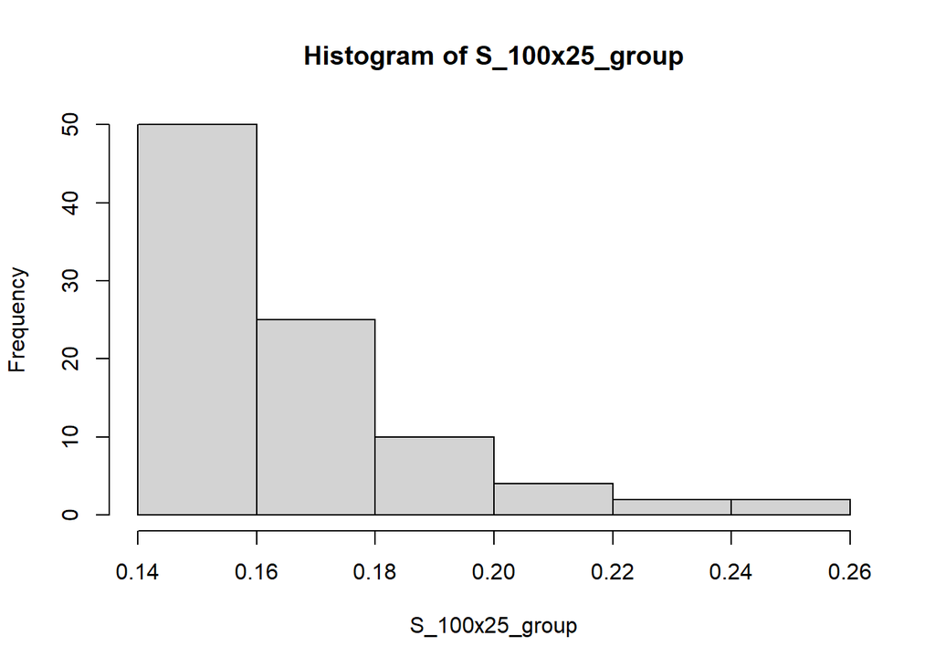

```r
# df_list2 <- lapply(seeds3, function(seed) readRDS(paste('output/df__sim_', seed, '_N_', N, '_T_', Nt, '_O1_6_O2_3_L1_2.RDS', sep='')))
# names(df_list2) <- paste0('df_100x25_', seeds3)
# list2env(df_list2, envir = .GlobalEnv)
#
# filter_list2 <- lapply(seeds3, function(seed) readRDS(paste('output/filter__sim_', seed, '_N_', N, '_T_', Nt, '_O1_6_O2_3_L1_2.RDS', sep='')))
# names(filter_list2) <- paste0('filter_100x25_', seeds3)
# list2env(filter_list2, envir = .GlobalEnv)

S_100x25_group <- unlist(lapply(df_list2, function(df) mean(df$S[,Nt]==2)))
hist(S_100x25_group)
```

```r
summary(S_100x25_group)
```

```
##    Min. 1st Qu.  Median    Mean 3rd Qu.    Max.
##  0.1400  0.1500  0.1600  0.1666  0.1700  0.2600
```

```r
length(seeds2)
```

```
## [1] 93
```

First, we check the distribution of the resulting **sumLik** in log scale.

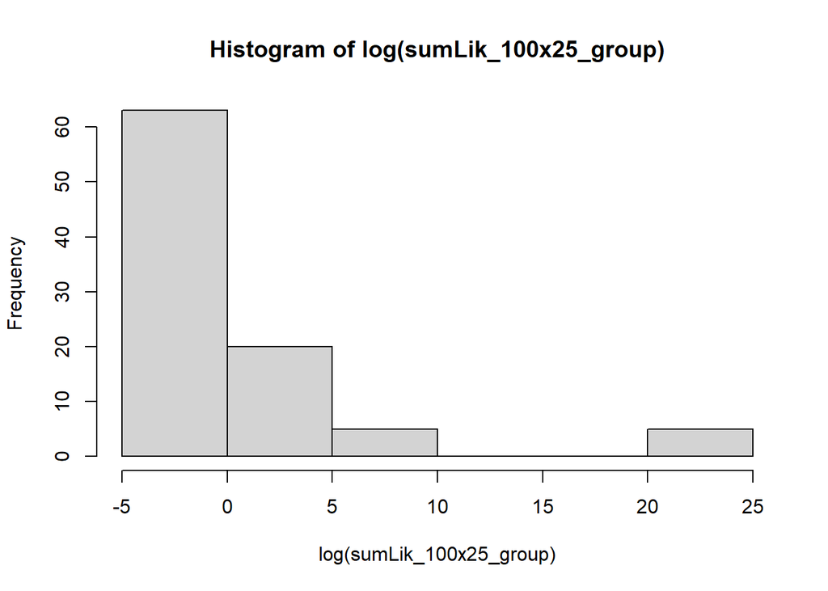

```r
sumLik_100x25_group <- unlist(lapply(filter_list2, function(filter) filter$sumLik_best_NT))
hist(log(sumLik_100x25_group))
```

```r
summary(log(sumLik_100x25_group))
```

```
##    Min. 1st Qu.  Median    Mean 3rd Qu.    Max.
## -4.1673 -3.2881 -2.7436 -0.1742  0.4293 22.2991
```

```r
sort(sumLik_100x25_group)
```

```
##  filter_100x25_96  filter_100x25_46  filter_100x25_77  filter_100x25_60
##      1.549397e-02      2.557487e-02      2.602401e-02      2.653583e-02
##  filter_100x25_74  filter_100x25_13 filter_100x25_108  filter_100x25_34
##      2.763207e-02      2.802840e-02      2.838247e-02      2.903725e-02
##  filter_100x25_94 filter_100x25_182  filter_100x25_17  filter_100x25_11
##      3.064765e-02      3.082339e-02      3.128227e-02      3.134385e-02
## filter_100x25_132 filter_100x25_175 filter_100x25_124 filter_100x25_166
##      3.152574e-02      3.184547e-02      3.408383e-02      3.491765e-02
##  filter_100x25_51   filter_100x25_7  filter_100x25_61  filter_100x25_93
##      3.543553e-02      3.572089e-02      3.582256e-02      3.610265e-02
##  filter_100x25_87  filter_100x25_58  filter_100x25_98   filter_100x25_6
##      3.667301e-02      3.702335e-02      3.715190e-02      3.732479e-02
## filter_100x25_181  filter_100x25_16 filter_100x25_161  filter_100x25_75
##      3.771128e-02      3.794712e-02      3.982169e-02      4.058804e-02
## filter_100x25_198 filter_100x25_169  filter_100x25_39  filter_100x25_45
##      4.092077e-02      4.323716e-02      4.433237e-02      4.439722e-02
## filter_100x25_199 filter_100x25_176 filter_100x25_100  filter_100x25_18
##      4.496797e-02      4.579152e-02      4.609559e-02      4.630426e-02
## filter_100x25_152  filter_100x25_26  filter_100x25_27 filter_100x25_163
##      4.634725e-02      4.710346e-02      4.929342e-02      5.010336e-02
## filter_100x25_200  filter_100x25_54  filter_100x25_41  filter_100x25_21
##      5.045468e-02      5.148301e-02      5.184779e-02      5.439340e-02
## filter_100x25_179 filter_100x25_120  filter_100x25_12 filter_100x25_115
##      5.767454e-02      5.875132e-02      6.434096e-02      6.465115e-02
## filter_100x25_167 filter_100x25_186 filter_100x25_162  filter_100x25_48
##      6.737050e-02      6.859426e-02      6.887680e-02      7.333119e-02
## filter_100x25_123 filter_100x25_178  filter_100x25_72  filter_100x25_19
##      7.444072e-02      8.182069e-02      8.662205e-02      9.190106e-02
##  filter_100x25_71 filter_100x25_135  filter_100x25_38 filter_100x25_118
##      9.486595e-02      9.825955e-02      9.910887e-02      1.005793e-01
## filter_100x25_106  filter_100x25_67 filter_100x25_180  filter_100x25_32
##      1.036603e-01      1.038230e-01      1.094836e-01      1.024486e+00
## filter_100x25_138 filter_100x25_114 filter_100x25_144 filter_100x25_139
##      1.142107e+00      1.240126e+00      1.340086e+00      1.411907e+00
## filter_100x25_197  filter_100x25_47 filter_100x25_103  filter_100x25_36
##      1.533338e+00      1.536172e+00      1.932315e+00      1.974737e+00
##  filter_100x25_15 filter_100x25_109 filter_100x25_184  filter_100x25_68
##      5.240954e+00      7.649829e+00      8.458457e+00      9.420761e+00
##  filter_100x25_78  filter_100x25_55  filter_100x25_29 filter_100x25_129
##      1.092458e+01      1.351946e+01      1.640515e+01      3.059655e+01
##  filter_100x25_56 filter_100x25_168 filter_100x25_128 filter_100x25_194
##      7.368547e+01      1.030621e+02      1.400939e+02      1.543984e+02
## filter_100x25_171 filter_100x25_164  filter_100x25_81 filter_100x25_137
##      2.146394e+02      3.558743e+02      1.759804e+03      1.974041e+03
##  filter_100x25_99 filter_100x25_147  filter_100x25_89  filter_100x25_69
##      1.402996e+09      2.822502e+09      3.186985e+09      4.054809e+09
##  filter_100x25_42
##      4.834601e+09
```

It seems like there are a few instances which has much higher **sumLik** than others.

Second, we check the distribution of the resulting **delta** in log scale.

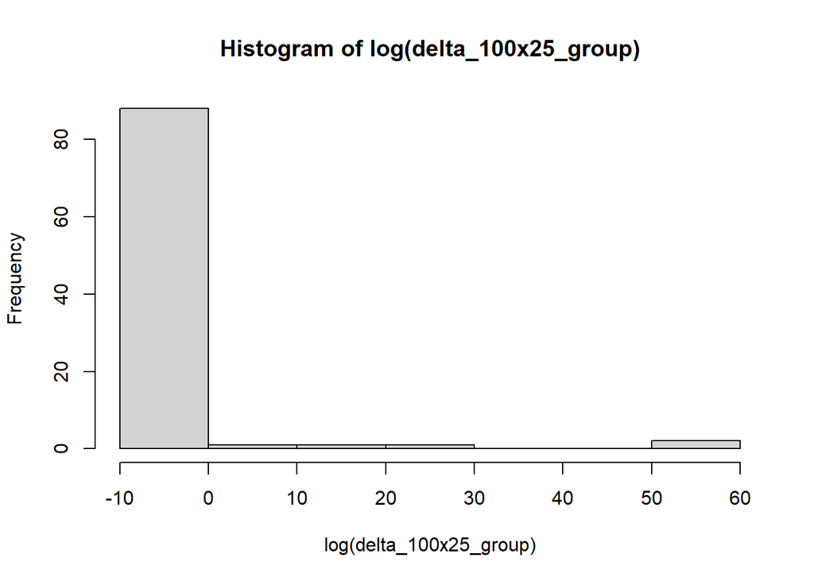

```r
delta_100x25_group <- unlist(lapply(filter_list2, function(filter) filter$delta_N))
hist(log(delta_100x25_group))
```

```r
summary(log(delta_100x25_group))
```

```
##    Min. 1st Qu.  Median    Mean 3rd Qu.    Max.
## -1.9677 -1.4743 -1.3352  0.3553 -1.1274 55.3743
```

Please note that we prefer a smaller value as it is calculated based on the prediction error.

Next, we turn our attention to how the **sumLik** and **delta** correlate (in log scale). Intuitively, we expect the negative correlation so that higher **sumLik** (maximized likelihood) relates to smaller **delta** (smaller prediction error).

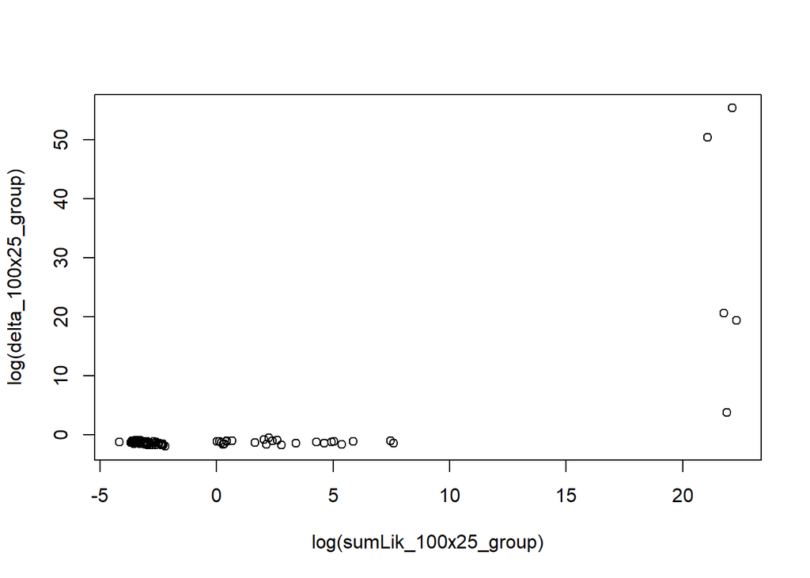

```r
plot(log(sumLik_100x25_group), log(delta_100x25_group))
```

```r
cor(log(sumLik_100x25_group), log(delta_100x25_group))
```

```
## [1] 0.7369342
```

Then, we check the distribution of **sensitivity** and **specificity**. First for **accuracy**

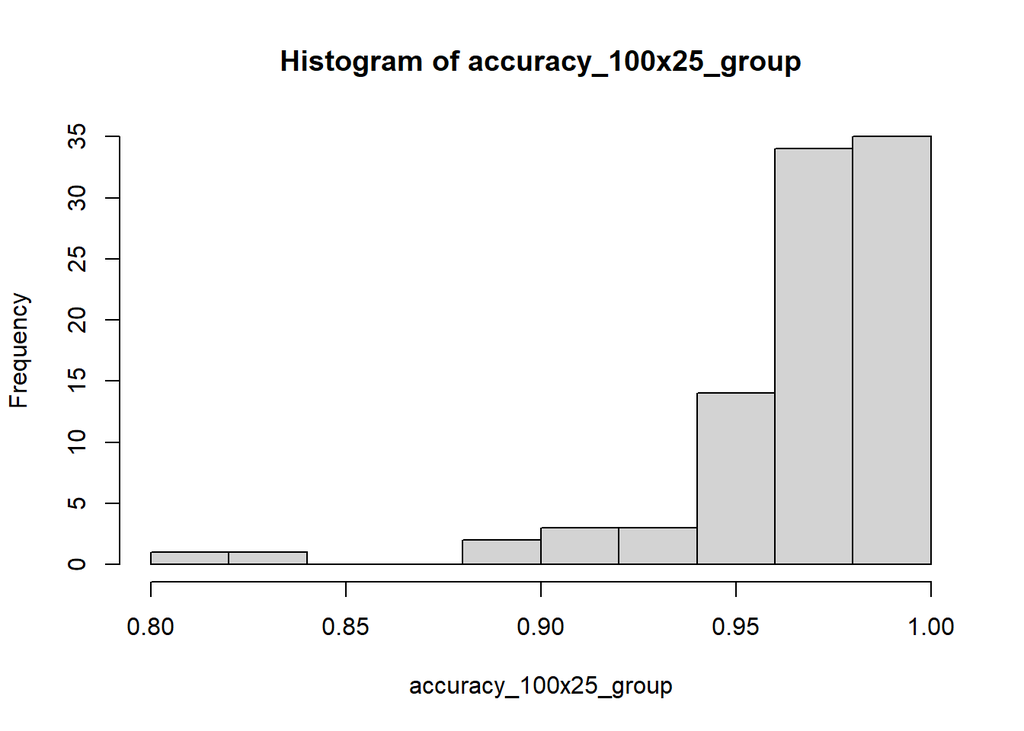

```r
accuracy_100x25_group <- unlist(lapply(filter_list2, function(filter) (filter$output_best$TP + filter$output_best$TN) / N))
hist(accuracy_100x25_group)
```

```r
summary(accuracy_100x25_group)
```

```
##    Min. 1st Qu.  Median    Mean 3rd Qu.    Max.
##  0.8000  0.9600  0.9800  0.9713  0.9900  1.0000
```

Then for **sensitivity**

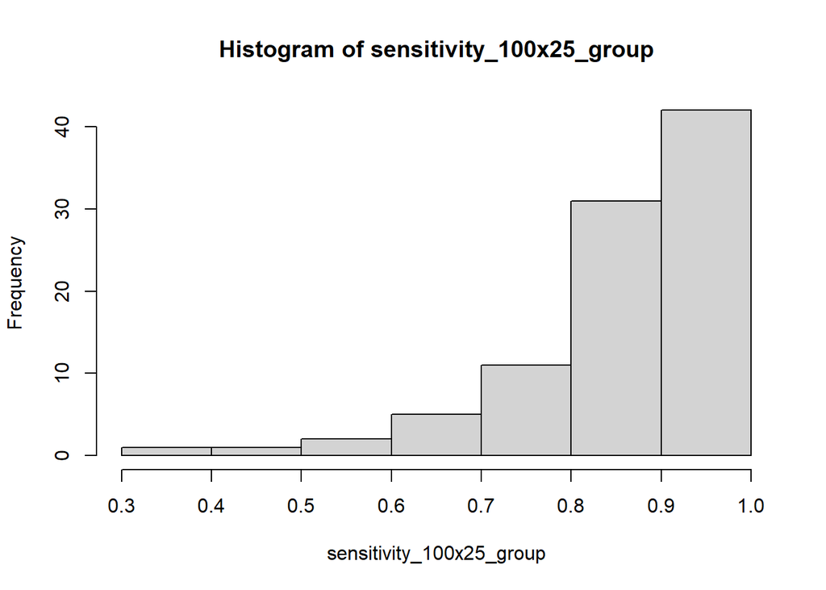

```r
sensitivity_100x25_group <- unlist(lapply(filter_list2, function(filter) filter$output_best$sensitivity))
hist(sensitivity_100x25_group)
```

```r
summary(sensitivity_100x25_group)
```

```
##    Min. 1st Qu.  Median    Mean 3rd Qu.    Max.
##  0.3684  0.8333  0.8824  0.8759  1.0000  1.0000
```

```r
sum(sensitivity_100x25_group<0.8)/length(seeds2)
```

```
## [1] 0.2150538
```

And for **specificity**

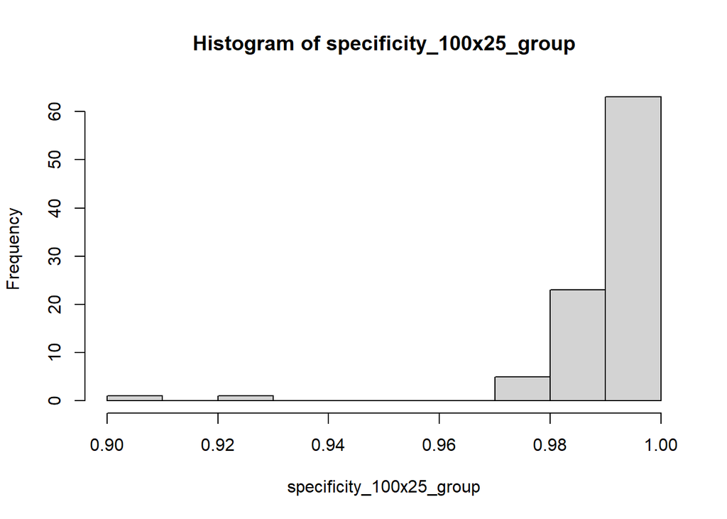

```r
specificity_100x25_group <- unlist(lapply(filter_list2, function(filter) filter$output_best$specificity))
hist(specificity_100x25_group)
```

```r
summary(specificity_100x25_group)
```

```
##    Min. 1st Qu.  Median    Mean 3rd Qu.    Max.
##  0.9012  0.9884  1.0000  0.9940  1.0000  1.0000
```

We can also check the correlation between **sensitivity** and **specificity**.

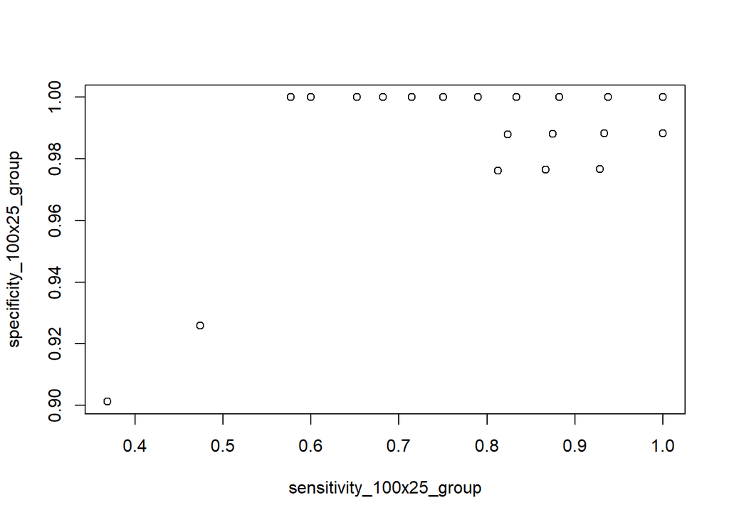

```r
plot(sensitivity_100x25_group, specificity_100x25_group)
```

```r
cor(sensitivity_100x25_group, specificity_100x25_group)
```

```
## [1] 0.3651597
```

Finally we examine our parameter estimation. The distribution of parameter estimation are shown below. True parameter values are in parenthesis.

```r
theta_100x25_group <- do.call(rbind, lapply(filter_list2, function(filter) filter$theta_best))
colnames(theta_100x25_group) <- c('B11_1 (.2)', 'B11_2 (.3)', 'B12_1 (-.1)', 'B12_2 (-.2)', 'B21d_1 (.8)', 'B21d_2 (.8)', 'B22d_1 (.4)', 'B22d_2 (.4)', 'B31_1 (.1)', 'B31_2 (.1)', 'B32_1 (-.1)', 'B32_2 (-.1)', 'Lmdd_1 (1)', 'Lmdd_2 (0)', 'Lmdd_3 (.4)', 'Lmdd_4 (0)', 'Lmdd_5 (.8)', 'Lmdd_6 (0)', 'Lmdd_7 (0)', 'Lmdd_8 (1)', 'Lmdd_9 (0)', 'Lmdd_10 (.5)', 'Lmdd_11 (0)', 'Lmdd_12 (1.2)', 'Qd_1 (.2)', 'Qd_2 (.2)', 'Rd_1 (.3)', 'Rd_2 (.3)', 'Rd_3 (.3)', 'Rd_4 (.3)', 'Rd_5 (.3)', 'Rd_6 (.3)', 'gamma1 (3.5)', 'gamma2_1 (1)', 'gamma2_2 (1)')
summary(theta_100x25_group)
```

```
##    B11_1 (.2)         B11_2 (.3)        B12_1 (-.1)        B12_2 (-.2)
##  Min.   :-0.01527   Min.   :-0.01651   Min.   :-0.62611   Min.   :-0.5304
##  1st Qu.: 0.08021   1st Qu.: 0.11257   1st Qu.:-0.23011   1st Qu.:-0.2738
##  Median : 0.12350   Median : 0.16132   Median :-0.15324   Median :-0.1804
##  Mean   : 0.15640   Mean   : 0.20556   Mean   :-0.17338   Mean   :-0.1900
##  3rd Qu.: 0.18299   3rd Qu.: 0.25412   3rd Qu.:-0.09935   3rd Qu.:-0.1137
##  Max.   : 0.77047   Max.   : 0.62777   Max.   :-0.01233   Max.   : 0.1286
##   B21d_1 (.8)      B21d_2 (.8)      B22d_1 (.4)        B22d_2 (.4)
##  Min.   :0.4929   Min.   :0.5361   Min.   :-0.01191   Min.   :-0.02454
##  1st Qu.:0.7513   1st Qu.:0.7950   1st Qu.: 0.14382   1st Qu.: 0.11142
##  Median :0.8354   Median :0.8702   Median : 0.26324   Median : 0.21907
##  Mean   :0.8166   Mean   :0.8410   Mean   : 0.24916   Mean   : 0.22554
##  3rd Qu.:0.8904   3rd Qu.:0.9114   3rd Qu.: 0.35560   3rd Qu.: 0.34282
##  Max.   :1.0005   Max.   :1.0932   Max.   : 0.48244   Max.   : 0.47801
##    B31_1 (.1)          B31_2 (.1)        B32_1 (-.1)        B32_2 (-.1)
##  Min.   :-0.338132   Min.   :-0.32823   Min.   :-0.26274   Min.   :-0.51070
##  1st Qu.: 0.007845   1st Qu.:-0.01042   1st Qu.:-0.12349   1st Qu.:-0.14563
##  Median : 0.062482   Median : 0.05185   Median :-0.08359   Median :-0.06320
##  Mean   : 0.079100   Mean   : 0.06652   Mean   :-0.07326   Mean   :-0.08262
##  3rd Qu.: 0.136237   3rd Qu.: 0.15688   3rd Qu.:-0.02174   3rd Qu.:-0.01776
##  Max.   : 0.485016   Max.   : 0.41882   Max.   : 0.25562   Max.   : 0.21095
##    Lmdd_1 (1)   Lmdd_2 (0)  Lmdd_3 (.4)       Lmdd_4 (0)  Lmdd_5 (.8)
##  Min.   :1    Min.   :0    Min.   :0.1945   Min.   :0    Min.   :0.4931
##  1st Qu.:1    1st Qu.:0    1st Qu.:0.6074   1st Qu.:0    1st Qu.:0.7772
##  Median :1    Median :0    Median :0.8861   Median :0    Median :0.9361
##  Mean   :1    Mean   :0    Mean   :0.8564   Mean   :0    Mean   :0.9617
##  3rd Qu.:1    3rd Qu.:0    3rd Qu.:1.0626   3rd Qu.:0    3rd Qu.:1.1415
##  Max.   :1    Max.   :0    Max.   :1.3731   Max.   :0    Max.   :1.3654
##    Lmdd_6 (0)   Lmdd_7 (0)   Lmdd_8 (1)   Lmdd_9 (0)  Lmdd_10 (.5)
##  Min.   :0    Min.   :0    Min.   :1    Min.   :0    Min.   :0.3895
##  1st Qu.:0    1st Qu.:0    1st Qu.:1    1st Qu.:0    1st Qu.:0.6216
##  Median :0    Median :0    Median :1    Median :0    Median :0.8633
##  Mean   :0    Mean   :0    Mean   :1    Mean   :0    Mean   :0.8649
##  3rd Qu.:0    3rd Qu.:0    3rd Qu.:1    3rd Qu.:0    3rd Qu.:1.1224
##  Max.   :0    Max.   :0    Max.   :1    Max.   :0    Max.   :1.3755
##   Lmdd_11 (0) Lmdd_12 (1.2)      Qd_1 (.2)          Qd_2 (.2)
##  Min.   :0    Min.   :0.6467   Min.   :0.001000   Min.   :0.001000
##  1st Qu.:0    1st Qu.:0.9177   1st Qu.:0.004273   1st Qu.:0.006755
##  Median :0    Median :1.0843   Median :0.173008   Median :0.172499
##  Mean   :0    Mean   :1.0836   Mean   :0.118793   Mean   :0.118754
```

[output cut: 8 more lines]

```
##  Max.   :0.37842   Max.   :0.37652   Max.   :0.37739   Max.   :0.39179
##    Rd_5 (.3)         Rd_6 (.3)        gamma1 (3.5)    gamma2_1 (1)
##  Min.   :0.02062   Min.   :0.04769   Min.   :4.049   Min.   :-0.04767
##  1st Qu.:0.12741   1st Qu.:0.14167   1st Qu.:4.122   1st Qu.: 0.48931
##  Median :0.37341   Median :0.37300   Median :4.124   Median : 0.85377
##  Mean   :0.27959   Mean   :0.28627   Mean   :4.224   Mean   : 0.91322
##  3rd Qu.:0.37509   3rd Qu.:0.37419   3rd Qu.:4.364   3rd Qu.: 1.17154
##  Max.   :0.37764   Max.   :0.37711   Max.   :4.630   Max.   : 2.19817
##   gamma2_2 (1)
##  Min.   :0.1312
##  1st Qu.:0.5173
##  Median :0.8391
##  Mean   :0.9650
##  3rd Qu.:1.2404
##  Max.   :2.8608
```

Finally, we check the rate of regime-switch prediction by the time of the final prediction which we call the dropout prediction rate.

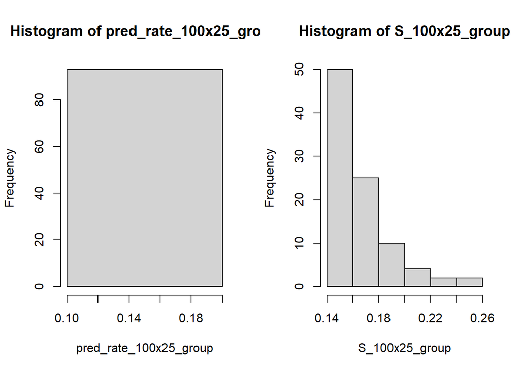

```r
par(mfrow = c(1, 2))
pred_rate_100x25_group <- unlist(lapply(filter_list2, function(filter) (filter$output_best$TP + filter$output_best$FP) / N))
hist(pred_rate_100x25_group)
hist(S_100x25_group)
```

```r
summary(pred_rate_100x25_group)
```

```
##    Min. 1st Qu.  Median    Mean 3rd Qu.    Max.
##    0.15    0.15    0.15    0.15    0.15    0.15
```

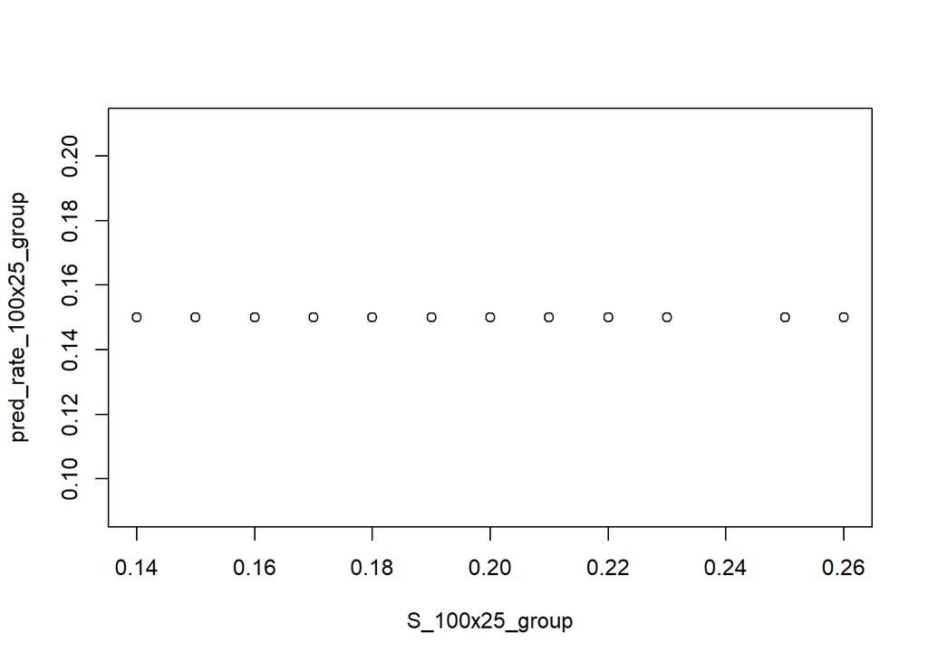

```r
plot(S_100x25_group, pred_rate_100x25_group)
```

```r
cor(S_100x25_group, pred_rate_100x25_group)
```

```
## [1] NA
```

```r
(worst_100 <- which.min(sensitivity_100x25_group))
```

```
## filter_100x25_69
##               35
```

```r
(worst2_100 <- which(sensitivity_100x25_group<0.5)[1])
```

```
## filter_100x25_55
##               28
```

```r
S_100x25_group[worst_100]
```

```
## df_100x25_69
##         0.19
```

```r
S_100x25_group[worst2_100]
```

```
## df_100x25_55
##         0.19
```

```r
summary(S_100x25_group)
```

```
##    Min. 1st Qu.  Median    Mean 3rd Qu.    Max.
##  0.1400  0.1500  0.1600  0.1666  0.1700  0.2600
```

```r
theta_100x25_group[worst_100,]
```

```
##    B11_1 (.2)    B11_2 (.3)   B12_1 (-.1)   B12_2 (-.2)   B21d_1 (.8)
##   0.080092616   0.144867778  -0.180586740  -0.238723874   0.874663711
##   B21d_2 (.8)   B22d_1 (.4)   B22d_2 (.4)    B31_1 (.1)    B31_2 (.1)
##   0.898570716   0.148515776   0.019315233   0.337301701   0.260173917
##   B32_1 (-.1)   B32_2 (-.1)    Lmdd_1 (1)    Lmdd_2 (0)   Lmdd_3 (.4)
##  -0.116708331  -0.012856027   1.000000000   0.000000000   0.507014155
##    Lmdd_4 (0)   Lmdd_5 (.8)    Lmdd_6 (0)    Lmdd_7 (0)    Lmdd_8 (1)
##   0.000000000   0.749960303   0.000000000   0.000000000   1.000000000
##    Lmdd_9 (0)  Lmdd_10 (.5)   Lmdd_11 (0) Lmdd_12 (1.2)     Qd_1 (.2)
##   0.000000000   0.493518412   0.000000000   1.020018935   0.001000000
##     Qd_2 (.2)     Rd_1 (.3)     Rd_2 (.3)     Rd_3 (.3)     Rd_4 (.3)
##   0.001789137   0.103554651   0.049558803   0.069819093   0.053765245
##     Rd_5 (.3)     Rd_6 (.3)  gamma1 (3.5)  gamma2_1 (1)  gamma2_2 (1)
##   0.036543865   0.063330799   4.434597492   1.380151868   0.640825748
```

```r
theta_100x25_group[worst2_100,]
```

```
##    B11_1 (.2)    B11_2 (.3)   B12_1 (-.1)   B12_2 (-.2)   B21d_1 (.8)
##   0.052769564   0.022325911  -0.288885415  -0.166370749   0.981426001
##   B21d_2 (.8)   B22d_1 (.4)   B22d_2 (.4)    B31_1 (.1)    B31_2 (.1)
##   0.962596416   0.114313543  -0.024540665   0.084097929  -0.115960322
##   B32_1 (-.1)   B32_2 (-.1)    Lmdd_1 (1)    Lmdd_2 (0)   Lmdd_3 (.4)
##  -0.083593778  -0.024897937   1.000000000   0.000000000   0.491247118
##    Lmdd_4 (0)   Lmdd_5 (.8)    Lmdd_6 (0)    Lmdd_7 (0)    Lmdd_8 (1)
##   0.000000000   0.931389987   0.000000000   0.000000000   1.000000000
##    Lmdd_9 (0)  Lmdd_10 (.5)   Lmdd_11 (0) Lmdd_12 (1.2)     Qd_1 (.2)
##   0.000000000   0.740150213   0.000000000   1.398171544   0.002543378
##     Qd_2 (.2)     Rd_1 (.3)     Rd_2 (.3)     Rd_3 (.3)     Rd_4 (.3)
##   0.001558484   0.070638962   0.045460358   0.065460533   0.071930066
##     Rd_5 (.3)     Rd_6 (.3)  gamma1 (3.5)  gamma2_1 (1)  gamma2_2 (1)
##   0.049718078   0.093748525   4.408063412   0.338965565   1.451002121
```

```r
colMeans(theta_100x25_group)
```

```
##    B11_1 (.2)    B11_2 (.3)   B12_1 (-.1)   B12_2 (-.2)   B21d_1 (.8)
##    0.15640356    0.20555624   -0.17337739   -0.19002899    0.81659716
##   B21d_2 (.8)   B22d_1 (.4)   B22d_2 (.4)    B31_1 (.1)    B31_2 (.1)
##    0.84102228    0.24916249    0.22553817    0.07910021    0.06652056
##   B32_1 (-.1)   B32_2 (-.1)    Lmdd_1 (1)    Lmdd_2 (0)   Lmdd_3 (.4)
##   -0.07325806   -0.08261947    1.00000000    0.00000000    0.85641882
##    Lmdd_4 (0)   Lmdd_5 (.8)    Lmdd_6 (0)    Lmdd_7 (0)    Lmdd_8 (1)
##    0.00000000    0.96165426    0.00000000    0.00000000    1.00000000
##    Lmdd_9 (0)  Lmdd_10 (.5)   Lmdd_11 (0) Lmdd_12 (1.2)     Qd_1 (.2)
##    0.00000000    0.86489095    0.00000000    1.08357457    0.11879252
##     Qd_2 (.2)     Rd_1 (.3)     Rd_2 (.3)     Rd_3 (.3)     Rd_4 (.3)
##    0.11875430    0.28832490    0.27843660    0.28092185    0.29224796
##     Rd_5 (.3)     Rd_6 (.3)  gamma1 (3.5)  gamma2_1 (1)  gamma2_2 (1)
##    0.27959139    0.28627153    4.22417915    0.91322148    0.96500889
```

```r
apply(theta_100x25_group, 2, median)
```

```
##    B11_1 (.2)    B11_2 (.3)   B12_1 (-.1)   B12_2 (-.2)   B21d_1 (.8)
##    0.12349730    0.16131961   -0.15323630   -0.18042906    0.83536679
##   B21d_2 (.8)   B22d_1 (.4)   B22d_2 (.4)    B31_1 (.1)    B31_2 (.1)
##    0.87017924    0.26323804    0.21906947    0.06248181    0.05185381
##   B32_1 (-.1)   B32_2 (-.1)    Lmdd_1 (1)    Lmdd_2 (0)   Lmdd_3 (.4)
##   -0.08359378   -0.06320230    1.00000000    0.00000000    0.88608825
##    Lmdd_4 (0)   Lmdd_5 (.8)    Lmdd_6 (0)    Lmdd_7 (0)    Lmdd_8 (1)
##    0.00000000    0.93608761    0.00000000    0.00000000    1.00000000
##    Lmdd_9 (0)  Lmdd_10 (.5)   Lmdd_11 (0) Lmdd_12 (1.2)     Qd_1 (.2)
##    0.00000000    0.86333901    0.00000000    1.08425283    0.17300768
##     Qd_2 (.2)     Rd_1 (.3)     Rd_2 (.3)     Rd_3 (.3)     Rd_4 (.3)
##    0.17249940    0.37466079    0.37354699    0.37318364    0.37398887
##     Rd_5 (.3)     Rd_6 (.3)  gamma1 (3.5)  gamma2_1 (1)  gamma2_2 (1)
##    0.37341395    0.37299815    4.12368584    0.85376543    0.83906442
```

```r
apply(theta_100x25_group, 2, sd)
```

```
##    B11_1 (.2)    B11_2 (.3)   B12_1 (-.1)   B12_2 (-.2)   B21d_1 (.8)
##    0.12640796    0.13924507    0.11292547    0.12683567    0.09600454
##   B21d_2 (.8)   B22d_1 (.4)   B22d_2 (.4)    B31_1 (.1)    B31_2 (.1)
##    0.10011057    0.14434391    0.14852698    0.13693472    0.11999310
##   B32_1 (-.1)   B32_2 (-.1)    Lmdd_1 (1)    Lmdd_2 (0)   Lmdd_3 (.4)
##    0.09157344    0.11128241    0.00000000    0.00000000    0.29369524
##    Lmdd_4 (0)   Lmdd_5 (.8)    Lmdd_6 (0)    Lmdd_7 (0)    Lmdd_8 (1)
##    0.00000000    0.21876786    0.00000000    0.00000000    0.00000000
##    Lmdd_9 (0)  Lmdd_10 (.5)   Lmdd_11 (0) Lmdd_12 (1.2)     Qd_1 (.2)
##    0.00000000    0.28050023    0.00000000    0.22948214    0.08037174
##     Qd_2 (.2)     Rd_1 (.3)     Rd_2 (.3)     Rd_3 (.3)     Rd_4 (.3)
##    0.07992418    0.13025537    0.14202929    0.13766922    0.12957390
##     Rd_5 (.3)     Rd_6 (.3)  gamma1 (3.5)  gamma2_1 (1)  gamma2_2 (1)
##    0.14077541    0.12973441    0.15892484    0.52634273    0.57778294
```